# Classification using Logistic Regression and Support Vector Machines

Ramya Deepthi Avula

# Business Problem

A grocery store chain sells two brands of orange juice- Minute Maid and Citrus Hill. Of these two, margins are more for Minute Maid and probably so, the brand manager and sales manager of the grocery store chain are interested in the performance of the brand, Minute Maid. Both of them want to improve the sales performance of this brand and since their job responsibilites are different, they need different types of information for it.

The brand manager wants to know the factors that increase the probability of the sales of Minute Maid. He wants to know what he should work upon to increase this probability. The sales manager is interested in just predicting the probability of a customer purchasing Minute Maid.

Also, both of them want to know how confident we are about the recommendations.

# Methods to be used

Since the brand manager wants to know the factors effecting the probability of sales of Minute Maid, we need to do descriptive analysis and find out the variables that effect the probability of sales of MM the most. I built a logistic regression and tested its in-sample and out-sample accuracy to see how good the predictors are in estimating the probability of buying MM. The coefficients estimates in the regression output are used to judge the effect of the predictors on the probability of sales.

The sales manager needs only a model that predicts the probability of buying MM as accurate as possible. Since he doesn’t need information about the predictors, a blackbox model that gives high accuracy can be used. I built a Support Vector Classification model for it and calculated in-sample and out-sample accuracy to determine how good the model is in the predictions.

While the logistics model alone will suffice to meet the requirements of both the sales manager and the brand manager, using support vector classification will give a higher accuracy with proper paramaeter tuning. So, if the details of predictors are not required, as in the case of sales manager’s requirements, using SVC is recommended.

## Scaling/Standardization:

I standardized the numeric predictors so as to compare between the effect of them on the target variable in the logistic regression. Without standardization, the predictors could be on different scales and comparing them is incorrect. Also, SVC works on the principle to maximize the distance between separating planes. If data is unstandardized, the predictors of large values will dominate others which affects the distance calculation.

In logistic regression, standardization is done while building the model using train() function of caret package. This ensures standardization of train and test datasets separately. In Support Vector Classification, to avoid data snooping, standardization is done on train and test data separately after the split.

## Reduce Overfitting:

In logistic regression, I will use 10 fold cross validation repeated 50 times. This is essentially splitting data into train and test in 90:10 ratio 50 times randomly. So train data will be different each of the 50 times and this ensures use of maximum data to train. Each time, the model is built on train and tested on the unused 10% test data set. The final accuracy in the output of the model is the average which is a good representation of the model performance on new data.

In case of SVC, first the data is split into 90:10 ratio. I want to train using more data to reduce overfitting. Again, using caret package, the model is built on train data alone and 10 fold cross validation is repeated for 10 times. Since there are other parameter combinations for which the model has to iterate, the repetition for cross validation is limited to 10 times to reduce the model running time.

# Data

The initial dataset loaded has 18 variables including the target variable “Purchase” which is a factor variable with levels “CH” and “MM”. CH stands for Citrus Hill and MM stands for Minute Maid. Of the 17 predictors, there are 5 factors and 12 numeric variables. However, the factor variables are in numeric format. These are changed to factors. The data also had many duplicate variables which are removed. This is explained in detail, later in this report. Some of the variables are very highly correlated. Correlation>0.75 is removed.

The following variables are used in building the logistic model.

Week of purchase- I have used this as a numeric predictor, this variable represents trend in the output if any.

StoreID- There are 5 stores with IDs 1,2,3,4,7. This is a factor variable.

Price CH and Price MM are numeric predictors that give the prices charged for CH and MM respectively.

Special CH and Special MM are factors with levels 0 and 1 where 0 implies no special promo applied on that transaction and 1 implies some special promo like loyalty points applied on the transaction.

LoyalCH captures the probability of buying CH over MM

SalePriceCH- Sale price of CH

PctDiscMM and PctDiscCH capture the percentage discount on MM and CH.

## Redundancy in data

The rest of the predictors are not used because they are either duplicates or highly correlated with one of the above predictors used. The duplicated predictors like “STORE” will have NAs in the model ouput, if used. If we use all predictors, multicollinearity among them will inflate the coefficients in the output. Also, using all the predictors will result in a overfitted model and while this might increase the in sample accuracy, out sample accuracy decreases which means the model predicitons on new data will be bad.

The same predictors used in logistic regression are used in support vector classification as well. One hot encoding of factor variables is done in addition.

All the analysis done is explained along with the code and output in this report.In case of support vector classification, the model is tried for a wide range of parameters and the best ones are shown in the report. Let’s look at the analysis now.

## Packages Used

dplyr, caret, dataPreparation, psych, mlbench, e1071, ROCR, kernlab

# Data Preprocessing

Let’s load the data and look at the structure and statistics of data.

```r
data<-read.csv(url("http://data.mishra.us/files/OJ.csv"))
str(data)
```

```
## 'data.frame':    1070 obs. of  18 variables:
##  $ Purchase      : Factor w/ 2 levels "CH","MM": 1 1 1 2 1 1 1 1 1 1 ...
##  $ WeekofPurchase: int  237 239 245 227 228 230 232 234 235 238 ...
##  $ StoreID       : int  1 1 1 1 7 7 7 7 7 7 ...
##  $ PriceCH       : num  1.75 1.75 1.86 1.69 1.69 1.69 1.69 1.75 1.75 1.75 ...
##  $ PriceMM       : num  1.99 1.99 2.09 1.69 1.69 1.99 1.99 1.99 1.99 1.99 ...
##  $ DiscCH        : num  0 0 0.17 0 0 0 0 0 0 0 ...
##  $ DiscMM        : num  0 0.3 0 0 0 0 0.4 0.4 0.4 0.4 ...
##  $ SpecialCH     : int  0 0 0 0 0 0 1 1 0 0 ...
##  $ SpecialMM     : int  0 1 0 0 0 1 1 0 0 0 ...
##  $ LoyalCH       : num  0.5 0.6 0.68 0.4 0.957 ...
##  $ SalePriceMM   : num  1.99 1.69 2.09 1.69 1.69 1.99 1.59 1.59 1.59 1.59 ...
##  $ SalePriceCH   : num  1.75 1.75 1.69 1.69 1.69 1.69 1.69 1.75 1.75 1.75 ...
##  $ PriceDiff     : num  0.24 -0.06 0.4 0 0 0.3 -0.1 -0.16 -0.16 -0.16 ...
##  $ Store7        : Factor w/ 2 levels "No","Yes": 1 1 1 1 2 2 2 2 2 2 ...
##  $ PctDiscMM     : num  0 0.151 0 0 0 ...
##  $ PctDiscCH     : num  0 0 0.0914 0 0 ...
##  $ ListPriceDiff : num  0.24 0.24 0.23 0 0 0.3 0.3 0.24 0.24 0.24 ...
##  $ STORE         : int  1 1 1 1 0 0 0 0 0 0 ...
```

```r
summary(data)
```

```
##  Purchase WeekofPurchase     StoreID        PriceCH         PriceMM
##  CH:653   Min.   :227.0   Min.   :1.00   Min.   :1.690   Min.   :1.690
##  MM:417   1st Qu.:240.0   1st Qu.:2.00   1st Qu.:1.790   1st Qu.:1.990
##           Median :257.0   Median :3.00   Median :1.860   Median :2.090
##           Mean   :254.4   Mean   :3.96   Mean   :1.867   Mean   :2.085
##           3rd Qu.:268.0   3rd Qu.:7.00   3rd Qu.:1.990   3rd Qu.:2.180
##           Max.   :278.0   Max.   :7.00   Max.   :2.090   Max.   :2.290
##      DiscCH            DiscMM         SpecialCH        SpecialMM
##  Min.   :0.00000   Min.   :0.0000   Min.   :0.0000   Min.   :0.0000
##  1st Qu.:0.00000   1st Qu.:0.0000   1st Qu.:0.0000   1st Qu.:0.0000
##  Median :0.00000   Median :0.0000   Median :0.0000   Median :0.0000
##  Mean   :0.05186   Mean   :0.1234   Mean   :0.1477   Mean   :0.1617
##  3rd Qu.:0.00000   3rd Qu.:0.2300   3rd Qu.:0.0000   3rd Qu.:0.0000
##  Max.   :0.50000   Max.   :0.8000   Max.   :1.0000   Max.   :1.0000
##     LoyalCH          SalePriceMM     SalePriceCH      PriceDiff
##  Min.   :0.000011   Min.   :1.190   Min.   :1.390   Min.   :-0.6700
##  1st Qu.:0.325257   1st Qu.:1.690   1st Qu.:1.750   1st Qu.: 0.0000
##  Median :0.600000   Median :2.090   Median :1.860   Median : 0.2300
##  Mean   :0.565782   Mean   :1.962   Mean   :1.816   Mean   : 0.1465
##  3rd Qu.:0.850873   3rd Qu.:2.130   3rd Qu.:1.890   3rd Qu.: 0.3200
##  Max.   :0.999947   Max.   :2.290   Max.   :2.090   Max.   : 0.6400
##  Store7      PctDiscMM        PctDiscCH       ListPriceDiff
##  No :714   Min.   :0.0000   Min.   :0.00000   Min.   :0.000
##  Yes:356   1st Qu.:0.0000   1st Qu.:0.00000   1st Qu.:0.140
##            Median :0.0000   Median :0.00000   Median :0.240
##            Mean   :0.0593   Mean   :0.02731   Mean   :0.218
##            3rd Qu.:0.1127   3rd Qu.:0.00000   3rd Qu.:0.300
##            Max.   :0.4020   Max.   :0.25269   Max.   :0.440
##      STORE
##  Min.   :0.000
##  1st Qu.:0.000
##  Median :2.000
##  Mean   :1.631
##  3rd Qu.:3.000
##  Max.   :4.000
```

We will make the below changes to data.

1.Subtract 226 from WeekofPurchase to bring down the week scale to 1-52 just for ease of understanding.Also, I’ll consider week a numeric variable to capture trend if any, so starting from 1 makes more sense for interpretation of model results.

2. StoreID, Store7, SpecialCH, SpecialMM, STORE are factor variables.Except Store7, rest of them are in numeric format. These should be converted to factors.

```r
data$WeekofPurchase <- data$WeekofPurchase-226
summary(data$WeekofPurchase)
```

```
##    Min. 1st Qu.  Median    Mean 3rd Qu.    Max.
##    1.00   14.00   31.00   28.38   42.00   52.00
```

```r
factors<- c("StoreID","SpecialCH", "SpecialMM","STORE")
data[,factors] <-lapply(data[,factors], factor)

summary(data)
```

```
##  Purchase WeekofPurchase  StoreID    PriceCH         PriceMM
##  CH:653   Min.   : 1.00   1:157   Min.   :1.690   Min.   :1.690
##  MM:417   1st Qu.:14.00   2:222   1st Qu.:1.790   1st Qu.:1.990
##           Median :31.00   3:196   Median :1.860   Median :2.090
##           Mean   :28.38   4:139   Mean   :1.867   Mean   :2.085
##           3rd Qu.:42.00   7:356   3rd Qu.:1.990   3rd Qu.:2.180
##           Max.   :52.00           Max.   :2.090   Max.   :2.290
##      DiscCH            DiscMM       SpecialCH SpecialMM    LoyalCH
##  Min.   :0.00000   Min.   :0.0000   0:912     0:897     Min.   :0.000011
##  1st Qu.:0.00000   1st Qu.:0.0000   1:158     1:173     1st Qu.:0.325257
##  Median :0.00000   Median :0.0000                       Median :0.600000
##  Mean   :0.05186   Mean   :0.1234                       Mean   :0.565782
##  3rd Qu.:0.00000   3rd Qu.:0.2300                       3rd Qu.:0.850873
##  Max.   :0.50000   Max.   :0.8000                       Max.   :0.999947
##   SalePriceMM     SalePriceCH      PriceDiff       Store7
##  Min.   :1.190   Min.   :1.390   Min.   :-0.6700   No :714
##  1st Qu.:1.690   1st Qu.:1.750   1st Qu.: 0.0000   Yes:356
##  Median :2.090   Median :1.860   Median : 0.2300
##  Mean   :1.962   Mean   :1.816   Mean   : 0.1465
##  3rd Qu.:2.130   3rd Qu.:1.890   3rd Qu.: 0.3200
##  Max.   :2.290   Max.   :2.090   Max.   : 0.6400
##    PctDiscMM        PctDiscCH       ListPriceDiff   STORE
##  Min.   :0.0000   Min.   :0.00000   Min.   :0.000   0:356
##  1st Qu.:0.0000   1st Qu.:0.00000   1st Qu.:0.140   1:157
##  Median :0.0000   Median :0.00000   Median :0.240   2:222
##  Mean   :0.0593   Mean   :0.02731   Mean   :0.218   3:196
##  3rd Qu.:0.1127   3rd Qu.:0.00000   3rd Qu.:0.300   4:139
##  Max.   :0.4020   Max.   :0.25269   Max.   :0.440
```

## Removing redundancy in dataset

On glimpse, StoreID, Store7 and STORE seem to capture the same information. There might be other duplicates. It’s good to confirm it statistically before we remove any of these.

```r
whichAreConstant(data)
```

```
## [1] "whichAreConstant: it took me 0.01s to identify 0 constant column(s)"
```

```
## integer(0)
```

```r
whichAreInDouble(data)
```

```
## [1] "whichAreInDouble: it took me 0.04s to identify 0 column(s) to drop."
```

```
## integer(0)
```

```r
whichAreBijection(data)
```

```
## [1] "whichAreBijection: STORE is a bijection of StoreID. I put it in drop list."
## [1] "whichAreBijection: it took me 0.64s to identify 1 column(s) to drop."
```

```
## [1] 18
```

```r
whichAreIncluded(data)
```

```
## [1] "whichAreIncluded: Store7 is included in column StoreID."
## [1] "whichAreIncluded: StoreID is included in column STORE."
## [1] "whichAreIncluded: DiscCH is included in column PctDiscCH."
## [1] "whichAreIncluded: DiscMM is included in column PctDiscMM."
```

```
## [1]  3  6  7 14
```

As expected, STORE is a bijection which means it’s exactly the same as StoreID. The variable “STORE” should be removed.Also Store7,DiscCH and DiscMM will be removed as they are included in other variables.

```r
data <- subset(data, select=-c(STORE,DiscCH,DiscMM,Store7))
```

Also, PriceDiff and ListPriceDiff seem to be derived from the SalePrice and Price variables. Let’s check this.

```r
cor(data$SalePriceMM-data$SalePriceCH,data$PriceDiff)
```

```
## [1] 1
```

```r
cor(data$PriceMM-data$PriceCH,data$ListPriceDiff)
```

```
## [1] 1
```

This confirms that PriceDiff can be derived from SalePriceMM & SalePriceCH, ListPriceDiff can be derived from PriceMM & PriceCH. So PriceDiff and ListPriceDiff can be removed.

```r
data<- subset(data,select=-c(PriceDiff,ListPriceDiff))
```

There are no other seemingly incorrect values in individual variables, so no further data cleaning is required at this stage.

Both the brand manager and sales manager are interested in just the brand “MM”. So let’s recode the target variable to Yes/No for ease of interpretation. Now, Purchase implies purchase of MM

```r
data$Purchase <- as.character(data$Purchase)
data$Purchase <- ifelse(data$Purchase=="MM","Yes","No")
data$Purchase <- as.factor(data$Purchase)
```

## MultiCollinearity

Let’s finally check for multicollinearity. Let’s choosing an arbitrary correlation value beyond which one of the correlated variables should be deleted.

```r
predictors <- data[,c(2:12)]

predictors_numeric <- select_if(predictors,is.numeric)
predictors_numeric%>%
  cor() %>%
  findCorrelation(cutoff = .75, names = T)
```

```
## [1] "SalePriceMM"
```

SalePriceMM is highly correlated(cor>0.75) with some other predictors in our dataset and removing this variable will ensure correlation<0.75 between any 2 predictors remaining.

```r
predictors <- subset(predictors, select= -SalePriceMM)
```

Now let’s combine the predictors with the target variable.

```r
df <-predictors
df$Purchase<- data$Purchase
```

There are still 2 things that we are to do before building the models- standardization and one hot encoding. The requirements of these are different for logistic and SVC models which is explained below. So, we will do them separately for the 2 models.

Logistic Regression: To compare between predictor coefficients in logistic regression, we need to standardize the predictors but we don’t necessarily need to do one hot encoding.

SVC: To build a SVC model, we need only numeric predictors, so we need to do one hot encoding.So, it requires both standardization and one hot encoding. We don’t want to standardize the one hot encoded factor variables.So, we will do standardization first followed by one hot encoding.

# Logistic Regression

Usin caret’s train() function to build the glm model, standardization can be taken care of within the function and also k-fold cross validation can be done.

```r
split=0.9
set.seed(123)
train_index <- sample(1:nrow(df), split * nrow(df))
test_index <- setdiff(1:nrow(df), train_index)
train_Data <- df[train_index]
X_test_unscaled <- df[test_index, -11]
y_test <- df[test_index, 11]

set.seed(123)
train.control <- trainControl(method = "repeatedcv", number = 10, repeats = 50)
# Train the model
model_glm <- train(Purchase ~., data = train_Data, method = "glm",
               trControl = train.control, preProcess=c("center","scale"))
# Summarize the results
print(model_glm)
```

```
## Generalized Linear Model
##
## 963 samples
##  10 predictor
##   2 classes: 'No', 'Yes'
##
## Pre-processing: centered (13), scaled (13)
## Resampling: Cross-Validated (10 fold, repeated 50 times)
## Summary of sample sizes: 867, 867, 867, 866, 867, 867, ...
## Resampling results:
##
##   Accuracy   Kappa
##   0.8267425  0.6336782
```

```r
summary(model_glm)
```

```
##
## Call:
## NULL
##
## Deviance Residuals:
##     Min       1Q   Median       3Q      Max
## -2.7554  -0.5614  -0.2423   0.5428   2.7796
##
## Coefficients:
##                 Estimate Std. Error z value Pr(>|z|)
## (Intercept)    -0.773095   0.098436  -7.854 4.04e-15 ***
## WeekofPurchase -0.100984   0.185674  -0.544 0.586524
## StoreID2        0.075041   0.117617   0.638 0.523464
## StoreID3       -0.004592   0.154819  -0.030 0.976340
## StoreID4       -0.138235   0.144754  -0.955 0.339595
## StoreID7       -0.280775   0.140442  -1.999 0.045584 *
## PriceCH         1.386885   1.951169   0.711 0.477210
## PriceMM        -0.425306   0.123760  -3.437 0.000589 ***
## SpecialCH1      0.089189   0.125563   0.710 0.477511
## SpecialMM1      0.115515   0.107286   1.077 0.281615
## LoyalCH        -1.857130   0.130099 -14.275  < 2e-16 ***
## SalePriceCH    -1.292264   2.755861  -0.469 0.639131
## PctDiscMM       0.428822   0.119723   3.582 0.000341 ***
## PctDiscCH      -1.526197   2.260464  -0.675 0.499568
## ---
## Signif. codes:  0 '***' 0.001 '**' 0.01 '*' 0.05 '.' 0.1 ' ' 1
##
## (Dispersion parameter for binomial family taken to be 1)
##
##     Null deviance: 1291.89  on 962  degrees of freedom
## Residual deviance:  755.52  on 949  degrees of freedom
## AIC: 783.52
##
## Number of Fisher Scoring iterations: 5
```

```r
(predict(model_glm)==train_Data$Purchase) %>%
  mean ##In-sample accuracy: 0.8349
```

```
## [1] 0.834891
```

Now let’s predict using this model on test data

```r
glmPred <- predict(model_glm, newdata = X_test_unscaled,
probability = TRUE)
confusionMatrix(data = glmPred, as.factor(y_test$Purchase))
```

```
## Confusion Matrix and Statistics
##
##           Reference
## Prediction No Yes
##        No  62   7
##        Yes  8  30
##
##                Accuracy : 0.8598
##                  95% CI : (0.7793, 0.9194)
##     No Information Rate : 0.6542
##     P-Value [Acc > NIR] : 1.438e-06
##
##                   Kappa : 0.6921
##  Mcnemar's Test P-Value : 1
##
##             Sensitivity : 0.8857
##             Specificity : 0.8108
##          Pos Pred Value : 0.8986
##          Neg Pred Value : 0.7895
##              Prevalence : 0.6542
##          Detection Rate : 0.5794
##    Detection Prevalence : 0.6449
##       Balanced Accuracy : 0.8483
##
##        'Positive' Class : No
##
```

## Model interpretation and performance:

The model’s in-sample(0.8349) and out-sample(0.8598) accuracies are very close, so there’s no overfitting, so it’s a good model. So, if we use this model to predict purchase of MM or CH, we will be correct roughly 85% of the time.

Since the predictors are standardized while building the model, the model coefficients are comparable.There are 4 significant coefficients. StoreID7, PriceMM, LoyalCH, PctDiscMM.

The descending order of the remaining 3 significant predictors based on their effect on target variable is:

PctDiscMM PriceMM StoreID7

The interpretation is as below.

Confidence Level: PriceMM, LoyalCH, PctDiscMM are significant at a level of p<0.001. This means we are 99.9% confident about the effect of these predictors. There is only 0.1% chance that the coefficients of these predictors are zero in the population, which implies 0.1% chance that these predictors don’t have effect on the probability of purchase of MM. Regarding StoreID7 we are 95% confident since it’s significant at a level of p<0.05. There is 5% chance that the log odds of purchasing MM in Store 7 is not different from Store 1.

## Recommendation to Brand Manager

1. Since LoyalCH is the significant predictor with highest effect, loyalty plays a huge role in purchase of a brand. The brand manager should focus on improving brand loyalty to Minute Maid. He could talk to loyal customers of both MM and CH and understand what keeps them loyal to their brands. Based on customer feedback, he could improve the desired features in MM. Promotion of Minute Maid and a good customer service will help increase brand loyalty.
2. Discounts have a positive effect on purchase of MM. While it cuts into margins from the brand, an optimum amount of discount so as to not cut too much into margins and yet increase the sales of MM reasonably should be determined. Other kind of indirect discounts like bundling MM with other products and offering discount on the whole bundle can be tried. This improves sales of MM and some other products in the grocery store.
3. Price is a major factor in sales of any product. It appears to have significant effect on MM as well.The negative coefficient of PriceMM implies there are some price sensitive customers. If it’s not economical to reduce price of Minute Maid, these price sensitive customers could be identified and special discount coupons can be emailed to them for purchasing MM.
4. The brand manager needs to look into the differences between Store 7 and the rest of the stores since Store7 has a negative coefficient which is significant. There might be many reasons for this. The placement of MM in the store might not be as good as Citrus Hill, there might be store level promotions for Citrus Hill, or Store 7 might be located in a low income, price sensitive area. The brand manager should maintain a customer feedback system for MM and CH here for a while and analyse the causes.

# Support Vector Classification

Let’s first split data into “train” and “test”. Here 90% of data randomly selected will be used for training and remaining 10% will be used to test the model performance.

```r
split=0.9
set.seed(123)
train_index <- sample(1:nrow(df), split * nrow(df))
test_index <- setdiff(1:nrow(df), train_index)
```

Now let’s separate predictors and target variable in both train and test data.

```r
X_train_unscaled <- df[train_index, -11]
y_train <- df[train_index, 11]
X_test_unscaled <- df[test_index, -11]
y_test <- df[test_index, 11]
```

## Standardization

Now the numeric predictors are standardized in both train and test separately.

```r
scales <- build_scales(dataSet = X_train_unscaled,
cols = "auto", verbose = FALSE)
X_train <- fastScale(dataSet = X_train_unscaled,
scales = scales, verbose = FALSE)
X_test <- fastScale(dataSet = X_test_unscaled,
scales = scales, verbose = FALSE)
```

## One hot encoding

Support vector classification can handle only numerical predictors. So, the factor variables in the predictors are encoded accordingly.

```r
encoding <- build_encoding(dataSet = X_train,
cols = "auto", verbose = FALSE)
X_train <- one_hot_encoder(dataSet = X_train,
encoding = encoding, drop = TRUE, verbose = FALSE)
X_test <- one_hot_encoder(dataSet = X_test, encoding = encoding,drop = TRUE, verbose = FALSE)

summary(X_train)
```

```
##  WeekofPurchase       PriceCH            PriceMM           LoyalCH
##  Min.   :-1.7320   Min.   :-1.71445   Min.   :-2.8859   Min.   :-1.82319
##  1st Qu.:-0.8983   1st Qu.:-0.73508   1st Qu.:-0.6806   1st Qu.:-0.78529
##  Median : 0.1277   Median :-0.04953   Median : 0.0545   Median : 0.08748
##  Mean   : 0.0000   Mean   : 0.00000   Mean   : 0.0000   Mean   : 0.00000
##  3rd Qu.: 0.8972   3rd Qu.: 1.22365   3rd Qu.: 0.7161   3rd Qu.: 0.93567
##  Max.   : 1.5385   Max.   : 2.20301   Max.   : 1.5247   Max.   : 1.42016
##   SalePriceCH        PctDiscMM         PctDiscCH         StoreID.1
##  Min.   :-2.9637   Min.   :-0.5770   Min.   :-0.4353   Min.   :0.0000
##  1st Qu.:-0.4462   1st Qu.:-0.5770   1st Qu.:-0.4353   1st Qu.:0.0000
##  Median : 0.3230   Median :-0.5770   Median :-0.4353   Median :0.0000
##  Mean   : 0.0000   Mean   : 0.0000   Mean   : 0.0000   Mean   :0.1506
##  3rd Qu.: 0.5328   3rd Qu.: 0.5339   3rd Qu.:-0.4353   3rd Qu.:0.0000
##  Max.   : 1.9314   Max.   : 3.3866   Max.   : 3.6369   Max.   :1.0000
##    StoreID.2        StoreID.3        StoreID.4        StoreID.7
##  Min.   :0.0000   Min.   :0.0000   Min.   :0.0000   Min.   :0.0000
##  1st Qu.:0.0000   1st Qu.:0.0000   1st Qu.:0.0000   1st Qu.:0.0000
##  Median :0.0000   Median :0.0000   Median :0.0000   Median :0.0000
##  Mean   :0.2118   Mean   :0.1817   Mean   :0.1298   Mean   :0.3261
##  3rd Qu.:0.0000   3rd Qu.:0.0000   3rd Qu.:0.0000   3rd Qu.:1.0000
##  Max.   :1.0000   Max.   :1.0000   Max.   :1.0000   Max.   :1.0000
##   SpecialCH.0      SpecialCH.1      SpecialMM.0      SpecialMM.1
##  Min.   :0.0000   Min.   :0.0000   Min.   :0.0000   Min.   :0.0000
##  1st Qu.:1.0000   1st Qu.:0.0000   1st Qu.:1.0000   1st Qu.:0.0000
##  Median :1.0000   Median :0.0000   Median :1.0000   Median :0.0000
##  Mean   :0.8619   Mean   :0.1381   Mean   :0.8328   Mean   :0.1672
##  3rd Qu.:1.0000   3rd Qu.:0.0000   3rd Qu.:1.0000   3rd Qu.:0.0000
##  Max.   :1.0000   Max.   :1.0000   Max.   :1.0000   Max.   :1.0000
```

One hot encoding has created dummys of factor variables, but for k levels in a factor, only k-1 dummies are needed. The remaining dummies are redundant. The same can be checked through looking for the variables which are included in other variables.

```r
whichAreIncluded(X_train)
```

```
## [1] "whichAreIncluded: SpecialCH.0 is included in column SpecialCH.1."
## [1] "whichAreIncluded: SpecialMM.0 is included in column SpecialMM.1."
```

```
## [1] 13 15
```

```r
whichAreIncluded(X_test)
```

```
## [1] "whichAreIncluded: SpecialCH.0 is included in column SpecialCH.1."
## [1] "whichAreIncluded: SpecialMM.0 is included in column SpecialMM.1."
```

```
## [1] 13 15
```

In case of SpecialCH.1, 1 means a special promotion applied and 0 means not applied. But for SpecialCH.0, 1 means no special promotion applied and 0 means it’s applied. So, between these 2 dummys, it’s better to remove SpecialCH.0 for ease of ineterpretation. Same logic applies for SpecialMM dummys.

```r
X_train<- subset(X_train,select=-c(SpecialCH.0,SpecialMM.0))
X_test <- subset(X_test,select=-c(SpecialCH.0,SpecialMM.0))
```

Still 5 levels of StoreID are in the dataset whereas we need only 4 dummys from these 5 levels. One of these can be deleted since “0” in all other StoreID variables will imply the deleted variable. I randomly pick StoreID.7

```r
X_train <- subset(X_train, select=-StoreID.7)
X_test <- subset(X_test, select=-StoreID.7)
```

We are done with the processing of the predictors as required to build SVC model. So now the predictors in train (X_train) can be combined with respective target variable(Y_train).

```r
train_Data <- cbind(y_train, X_train)
```

I’d like to do a 10-fold cross validation repeated 10 times. Also, let’s use grid() to specify the combination of hyperparameters that we want to use in our model.

```r
set.seed(123)
fitControl <- trainControl(method = "repeatedcv",number = 10,repeats = 10,
summaryFunction=twoClassSummary, classProbs = TRUE)

grid <- expand.grid(sigma = c(0.01,.015),
C = c(0.5,1,1.5))
```

## Building the model

Let’s test for the kernels “linear” and “radial”. Also we can look at the ROC curves for different values of sigma and costs. The sigma value for the curve with the highest area under it is the best and the cost at which the curve is at its highest is the best.

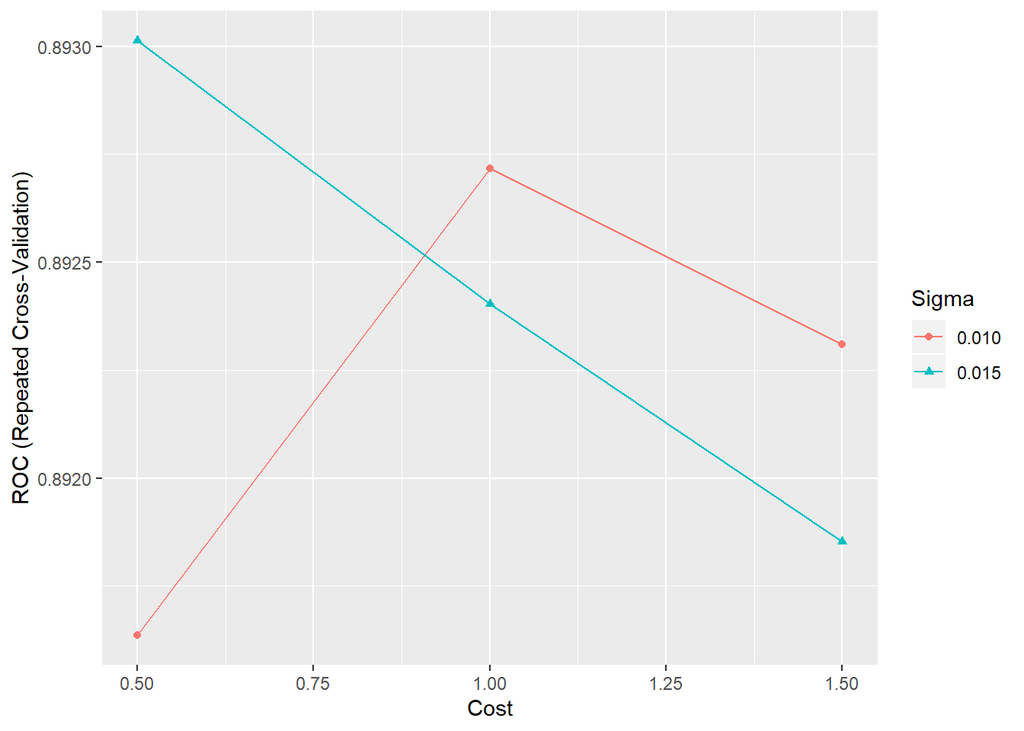

```r
svm_Radial <- train(Purchase ~ ., data = train_Data,
method='svmRadial',
trControl = fitControl,
metric = "ROC",
verbose = FALSE,
probability = TRUE,
tuneGrid = grid
)

ggplot(svm_Radial)
```

```r
svm_Radial
```

```
## Support Vector Machines with Radial Basis Function Kernel
##
## 963 samples
##  13 predictor
##   2 classes: 'No', 'Yes'
##
## No pre-processing
## Resampling: Cross-Validated (10 fold, repeated 10 times)
## Summary of sample sizes: 867, 867, 867, 866, 867, 867, ...
## Resampling results across tuning parameters:
##
##   sigma  C    ROC        Sens       Spec
##   0.010  0.5  0.8916351  0.8780070  0.7413158
##   0.010  1.0  0.8927166  0.8759410  0.7476316
##   0.010  1.5  0.8923091  0.8786996  0.7489474
##   0.015  0.5  0.8930132  0.8756283  0.7436842
##   0.015  1.0  0.8924028  0.8768264  0.7486842
##   0.015  1.5  0.8918534  0.8792139  0.7397368
##
## ROC was used to select the optimal model using the largest value.
## The final values used for the model were sigma = 0.015 and C = 0.5.
```

After trying for different values of cost and sigma (more than what’s included in the code above), the best value of ROC is 0.8930132 for sigma=0.015 and C=0.5

```r
(predict(svm_Radial)==train_Data$Purchase) %>%
  mean ##In-sample accuracy: 0.8328
```

```
## [1] 0.8328141
```

Now let’s use the model on the test predictors dataset and calculate accuracy from confusion matrix

```r
svmPred <- predict(svm_Radial, newdata = X_test,
probability = TRUE)
confusionMatrix(data = svmPred, as.factor(y_test$Purchase))
```

```
## Confusion Matrix and Statistics
##
##           Reference
## Prediction No Yes
##        No  64   7
##        Yes  6  30
##
##                Accuracy : 0.8785
##                  95% CI : (0.8012, 0.9337)
##     No Information Rate : 0.6542
##     P-Value [Acc > NIR] : 1.163e-07
##
##                   Kappa : 0.7297
##  Mcnemar's Test P-Value : 1
##
##             Sensitivity : 0.9143
##             Specificity : 0.8108
##          Pos Pred Value : 0.9014
##          Neg Pred Value : 0.8333
##              Prevalence : 0.6542
##          Detection Rate : 0.5981
##    Detection Prevalence : 0.6636
##       Balanced Accuracy : 0.8625
##
##        'Positive' Class : No
##
```

The accuracy when the model is used for prediction on test data is 0.8785. The in-sample and out-sample accuracy values are quite close which indicates a good bias-variance balance.

The sales manager wants to know the probability of a customer purchasing MM. This can be obtained for any given customer in the following way.

```r
predictedProbs <- predict(svm_Radial, newdata = X_test , type = "prob")
head(predictedProbs)
```

```
##          No        Yes
## 1 0.8451815 0.15481854
## 2 0.3902759 0.60972406
## 3 0.9744403 0.02555968
## 4 0.9129260 0.08707403
## 5 0.9261691 0.07383086
## 6 0.9640762 0.03592382
```

Using these probabilities, we can set different thresholds to classify the data into the 2 classes. The default threshold is 0.5 when we directly predict classes instead of probability. Let’s verify this.

```r
predictedProbs$Purchase <- ifelse(predictedProbs$Yes>=0.5,"Yes","No")
predictedProbs$Purchase <- as.factor(predictedProbs$Purchase)
confusionMatrix(predictedProbs$Purchase,as.factor(y_test$Purchase))
```

```
## Confusion Matrix and Statistics
##
##           Reference
## Prediction No Yes
##        No  64   7
##        Yes  6  30
##
##                Accuracy : 0.8785
##                  95% CI : (0.8012, 0.9337)
##     No Information Rate : 0.6542
##     P-Value [Acc > NIR] : 1.163e-07
##
##                   Kappa : 0.7297
##  Mcnemar's Test P-Value : 1
##
##             Sensitivity : 0.9143
##             Specificity : 0.8108
##          Pos Pred Value : 0.9014
##          Neg Pred Value : 0.8333
##              Prevalence : 0.6542
##          Detection Rate : 0.5981
##    Detection Prevalence : 0.6636
##       Balanced Accuracy : 0.8625
##
##        'Positive' Class : No
##
```

The result above is exactly the same as what we have got by predicting the classes directly.

## SVC-Linear

Let’s also try linear model

```r
set.seed(123)
fitControl <- trainControl(method = "repeatedcv",number = 10,repeats = 10,
summaryFunction=twoClassSummary, classProbs = TRUE)

grid <- expand.grid(C = c(0.125,0.25,0.5,1))
```

```r
svm_Linear <- train(Purchase ~ ., data = train_Data,
method='svmLinear',
trControl = fitControl,
metric = "ROC",
verbose = FALSE,
probability = TRUE,
tuneGrid = grid
)
svm_Linear
```

```
## Support Vector Machines with Linear Kernel
##
## 963 samples
##  13 predictor
##   2 classes: 'No', 'Yes'
##
## No pre-processing
## Resampling: Cross-Validated (10 fold, repeated 10 times)
## Summary of sample sizes: 867, 867, 867, 866, 867, 867, ...
## Resampling results across tuning parameters:
##
##   C      ROC        Sens       Spec
##   0.125  0.8907590  0.8781590  0.7452632
##   0.250  0.8904601  0.8778112  0.7457895
##   0.500  0.8902524  0.8760988  0.7450000
##   1.000  0.8902647  0.8759205  0.7455263
##
## ROC was used to select the optimal model using the largest value.
## The final value used for the model was C = 0.125.
```

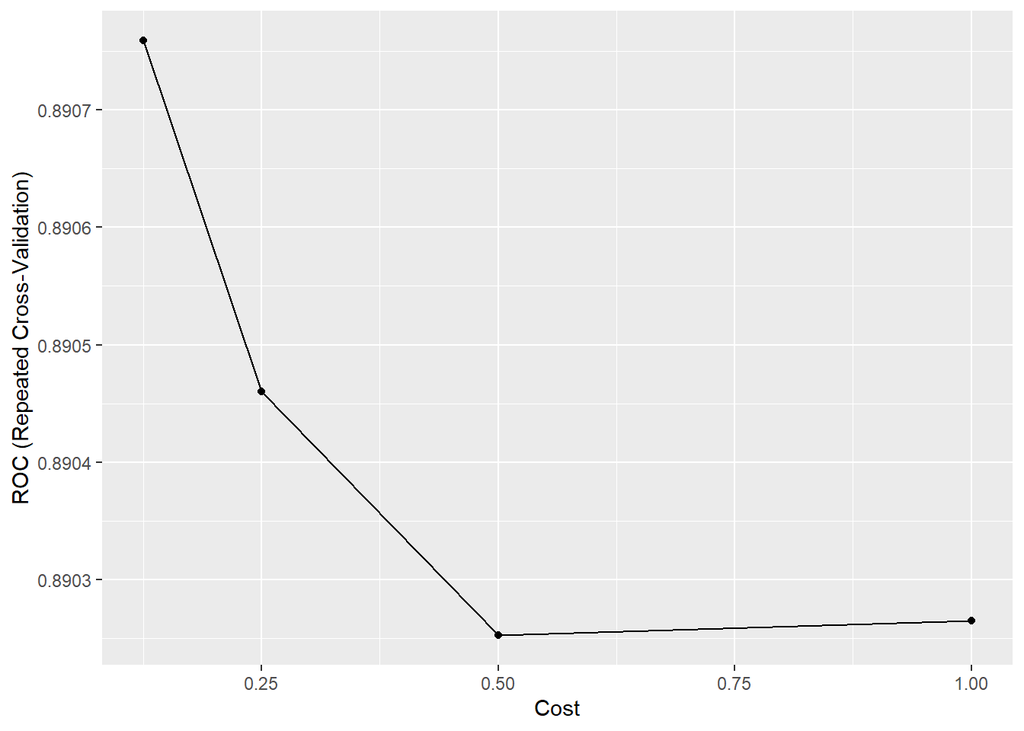

```r
ggplot(svm_Linear)
```

```r
svmPred <- predict(svm_Linear, newdata = X_test,
probability = TRUE)
confusionMatrix(data = svmPred, as.factor(y_test$Purchase))
```

```
## Confusion Matrix and Statistics
##
##           Reference
## Prediction No Yes
##        No  64   7
##        Yes  6  30
##
##                Accuracy : 0.8785
##                  95% CI : (0.8012, 0.9337)
##     No Information Rate : 0.6542
##     P-Value [Acc > NIR] : 1.163e-07
##
##                   Kappa : 0.7297
##  Mcnemar's Test P-Value : 1
##
##             Sensitivity : 0.9143
##             Specificity : 0.8108
##          Pos Pred Value : 0.9014
##          Neg Pred Value : 0.8333
##              Prevalence : 0.6542
##          Detection Rate : 0.5981
##    Detection Prevalence : 0.6636
##       Balanced Accuracy : 0.8625
##
##        'Positive' Class : No
##
```

## Predicting class probabilities

```r
predictedProbs <- predict(svm_Linear, newdata = X_test , type = "prob")

predictedProbs$Purchase <- ifelse(predictedProbs$Yes>=0.5,"Yes","No")
predictedProbs$Purchase <- as.factor(predictedProbs$Purchase)
confusionMatrix(predictedProbs$Purchase,as.factor(y_test$Purchase))
```

```
## Confusion Matrix and Statistics
##
##           Reference
## Prediction No Yes
##        No  64   7
##        Yes  6  30
##
##                Accuracy : 0.8785
##                  95% CI : (0.8012, 0.9337)
##     No Information Rate : 0.6542
##     P-Value [Acc > NIR] : 1.163e-07
##
##                   Kappa : 0.7297
##  Mcnemar's Test P-Value : 1
##
##             Sensitivity : 0.9143
##             Specificity : 0.8108
##          Pos Pred Value : 0.9014
##          Neg Pred Value : 0.8333
##              Prevalence : 0.6542
##          Detection Rate : 0.5981
##    Detection Prevalence : 0.6636
##       Balanced Accuracy : 0.8625
##
##        'Positive' Class : No
##
```

Using either svmRadial or svmLinear, the maximum out sample accuracy that I could reach with different cost and sigma(only in svmRadial) values is 87.85%

So using either of these SVC models, the sales manager can predict the probability of a customer purchasing MM with 87.85% accuracy which is a good improvement over logistic regression.

The p-value <0.001. I’m 99.9% confident about the model predictions. The limits for accuracy based on confidence interval are (0.8012,0.9337) The accuracy will not cross this interval.

## Recommendations to Sales Manager

I’d suggest to use the svc_Linear model since it’s giving the same accuracy as svc_Radial, but simpler than svc_Radial considering that it required one parameter less. I also suggest to use the model to predict the class probabilities instead of the class itself. By doing this, the sales manager will have the flexibility to choose the threshold for dividing into classes. Also, he will be able to classify the customers into multiple classes like low probability, average probability and high probability of purchasing MM. For each class, he could apply a different strategy to ensure purchase of MM at an optimum cost to the grocery chain. For example, he might want to spend more on promoting MM among the class with low purchase probability and don’t spend anything on the class with high purchase probability since they will buy MM anyway.

# Result and Conclusion

I have built a logistic regression model and 2 support vector classification models with radial and linear kernels.

The brand manager should use the results from the logisitic regression and focus on loyalty to brand, percentage discount on MM, price of MM and also Store 7 to improve purchase probability of MM.